# Quantitative Quality Control Approach

This report is meant to provide the script and figures for the Quantitative QC procedure. In addition to the visual quality control procedure, we wanted to eliminate some of the limitations of a pure visual QC such as: missing artefacts, fatigue, uncertainty of decision to include or exclude. Therefore, we decided to incorporate quantitative metrics of quality to supplement the visual QC. It’s important to note that these should supplement not particularly replace your visual ratings. There will be times when you’re visually rating scans that you may be very unsure of whether someone should be included or excluded, and this quantitative check will be very useful to help with that decision. Additionally, it is strongly recommended that if anyone fails the quantitative QC, that they are to be excluded as they may add a lot of noise to the analyses.

The quantitative QC is based on output metrics from eddy which are indicative of the quality of the diffusion image. These include:

Contrast to noise ratio: this metric provides an idea of how the different tissues in the brain will differentiate from each other. When there’s a high contrast to noise ratio, it means that there is enough contrast between brain tissue which will allow for good segmentation and will not bring in noise to the analysis.

Signal to noise ratio: similar to CNR, this metric is essentially the signal in a voxel divided by the standard deviation of the signal across a region outside the brain. When the SNR is high, that means that there is a good signal, and when it’s low, which means that there is a lot of noise which may influence the analysis and results.

Average relative motion: this is a metric of how much motion there is between two volumes. This type of motion can result in misalignment of the data and so the more motion there is, the greater the risk of artefacts.

Average absolute motion: this is a metric of how much motion there is within the whole scan. This can cause signal dropout which leads to problem with using the different diffusion metrics. - a caveat with this is when scans are concatenated. Some protocols scan participants in different sessions and then merge them together as if it was one scan, and in this case absolute motion may be superficially increased or decreased and may not be as meaningful as it should be. We discuss how to deal with this later on in the manual.

```r
df <- read.csv("file:///D:/UpgradedScripts/POND_eddy_metrics.csv")
```

```r
#loading necessary libraries
library(dplyr)
```

```r
library(ggplot2)
library(glue)
library(rmarkdown)
library(plotly)
library(readr)
library(stringr)
library(tidyr)
library(ggpubr)
library(cowplot)
library(gridExtra)
library(grid)
library(gridGraphics)
```

To better understand the data, it’s important to plot the distributions of the quality metrics to be used.

Note: If you have multi-shell data, then create a density plot for the CNR values of each B value. These will differ on a study to study basis.

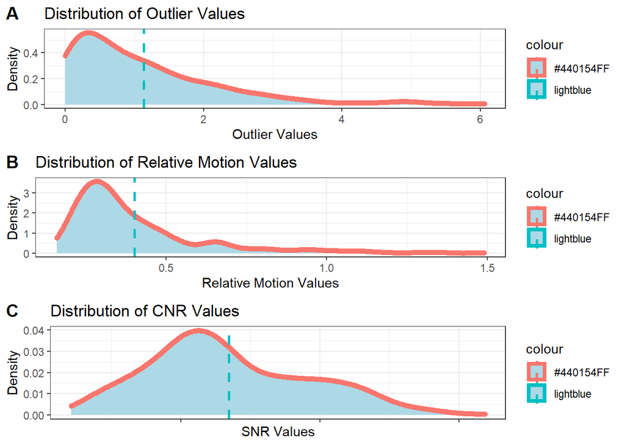

```r
### Density Plots of the diffusion metrics

density_plot_cnr1000 <- function(df) {
                   df2 <- df %>% filter(avg_cnr_1000 < 9999)
                   plot <- ggplot(df2, aes(x = avg_cnr_1000)) +
                                     geom_density(size = 2, aes(color = "#440154FF"), fill="lightblue") +
                                     geom_vline(data = df2, aes(xintercept = mean(avg_cnr_1000), color = "lightblue"), linetype = "dashed", size = 1) +
                                     labs(title = "Distribution of B1000 CNR Values", x = "B1000 CNR Values", y = "Density") +
                                     theme_bw()
                    return(plot)
}


density_plot_snr <- function(df) {
  df2 <- df %>% filter(avg_snr_0 < 9999)
  plot <- ggplot(df2, aes(x = avg_snr_0)) +
    geom_density(size = 2, aes(color = "#440154FF"), fill = "lightblue") +
    geom_vline(data = df2, aes(xintercept = mean(avg_snr_0), color = "lightblue"), linetype = "dashed", size = 1) +
    labs(title = "Distribution of CNR Values", x = "SNR Values", y = "Density") +
    theme_bw()
  return(plot)
}


density_plot_rel_mot <- function(df) {
  plot <- ggplot(df, aes(x = qc_mot_rel)) +
    geom_density(size = 2, aes(color = "#440154FF"), fill = "lightblue") +
    geom_vline(data = df, aes(xintercept = mean(qc_mot_rel), color = "lightblue"), linetype = "dashed", size = 1) +
    labs(title = "Distribution of Relative Motion Values", x = "Relative Motion Values", y = "Density") +
    theme_bw()
  return(plot)
}

density_plot_outliers <- function(df) {
  plot <- ggplot(df, aes(x = qc_outliers_tot)) +
    geom_density(size = 2, aes(color = "#440154FF"), fill = "lightblue") +
    geom_vline(data = df, aes(xintercept = mean(qc_outliers_tot), color = "lightblue"), linetype = "dashed", size = 1) +
    labs(title = "Distribution of Outlier Values", x = "Outlier Values", y = "Density") +
    theme_bw()
  return(plot)
}

plot_grid(density_plot_outliers(df), density_plot_rel_mot(df), density_plot_snr(df) + rremove("x.text"),
          labels = c("A", "B", "C"),
          ncol = 1, nrow = 3)
```

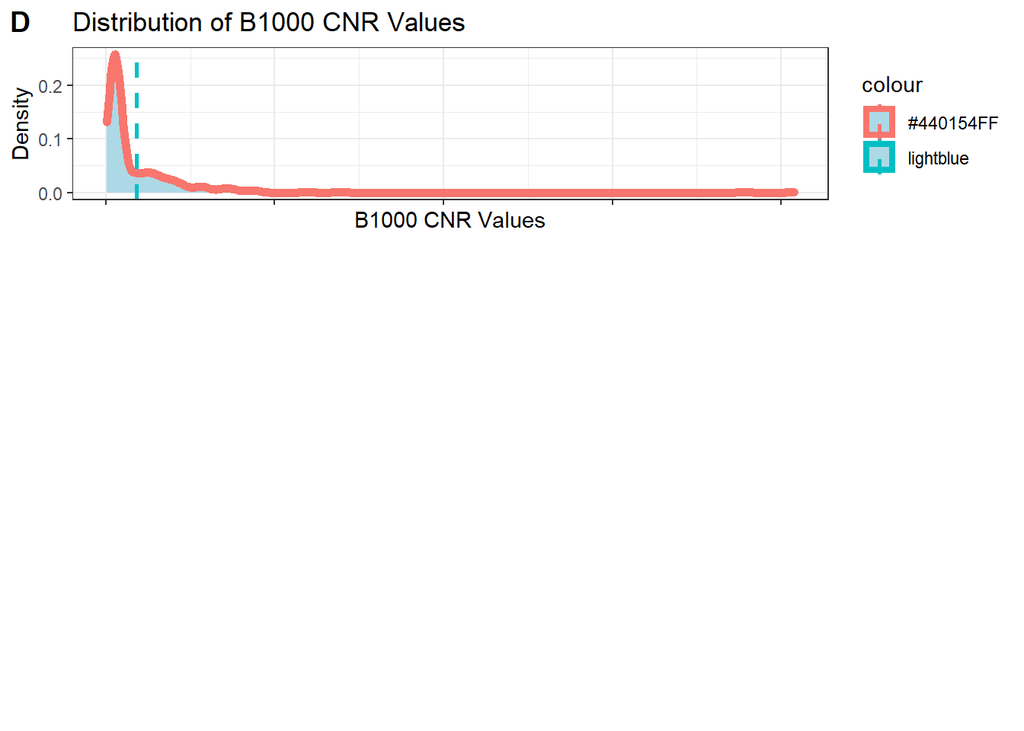

```r
plot_grid(density_plot_cnr1000(df) + rremove("x.text"),
          labels = c("D", "E", "F"),
          ncol = 1, nrow = 3)
```

Once you’ve visualized the data, the next step would be to determine the subjects who have poor quality metrics which we have defined as greater or less than two standard deviations from the mean. In some studies, you may find that your distribution is not Guassian and 2 STD may be excluding too many subjects, in that case, you can decide to exclude above 3 STD.

Note 1: when determining bad CNR and SNR, this script also filters for subjects with CNR and SNR that is above 2 STD because there may be a problem in the metrics when its too high (a CNR of 9999 doesn’t really make sense). It is not recommended that subjects with CNR or SNR that are above STD are removed from analysis, but they should be recognized for any metric based analysis.

Note 2: If your dataset has multishell acquisitions (as POND does), then make sure to check poor CNR for all the B value acquisitions

```r
#Excluding based on bad CNR

bad_cnr <- df %>%
  mutate(cnr_std = scale(avg_cnr_1000)) %>%
  filter(cnr_std < -2 | cnr_std > 2)


#Excluding based on bad SNR
bad_snr <- df %>%
  mutate(snr_std = scale(avg_snr_0)) %>%
  filter(snr_std < -2 | snr_std > 2)


#Excluding based on too much relative motion
bad_rel_mot <- df %>%
  mutate(rel_mot_std = scale(qc_mot_rel)) %>%
  filter(rel_mot_std > 2) #for motion, we're only concerned about participants with too much motion


#Excluding based on too many outliers
bad_outliers <- df %>%
  mutate(outliers_std = scale(qc_outliers_tot)) %>%
  filter(outliers_std > 2)  #for outliers, we're only concerned about participants with too many outliers
```

Once you’ve created the variable dataframes of the subjects excluded based on each quality metric, the next step would be to create a table with all the subjects excluded and the values of these metrics.